# Series 3 of 10 – How to Compare Two Groups with Robust Bayesian Estimation

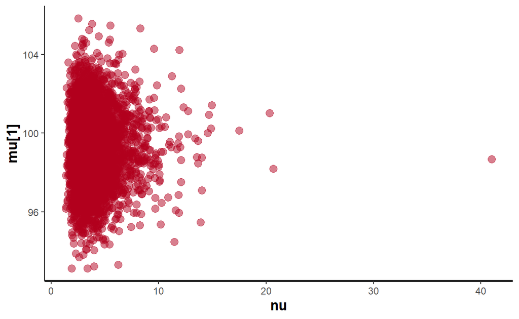

```r
stan_scat(stanFitRobust, c('nu','mu[1]'))
```

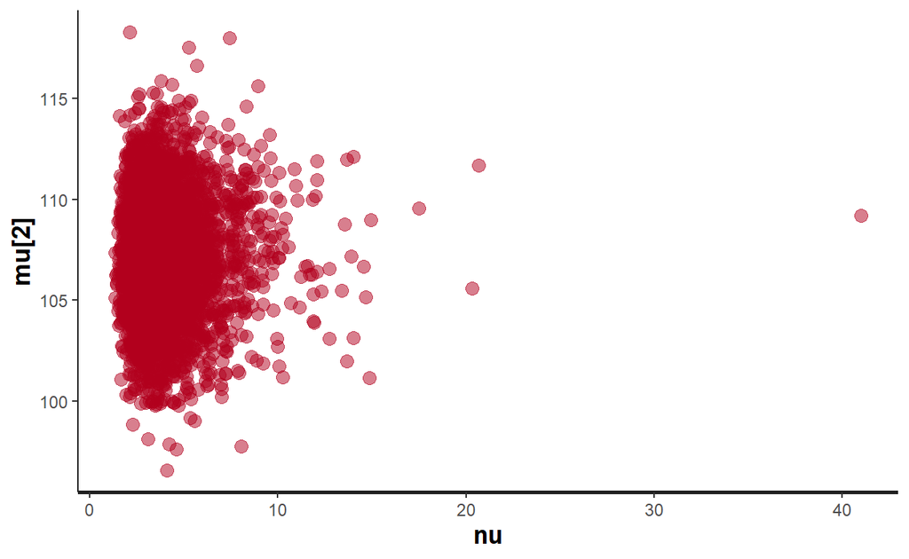

```r
stan_scat(stanFitRobust, c('nu','mu[2]'))
```

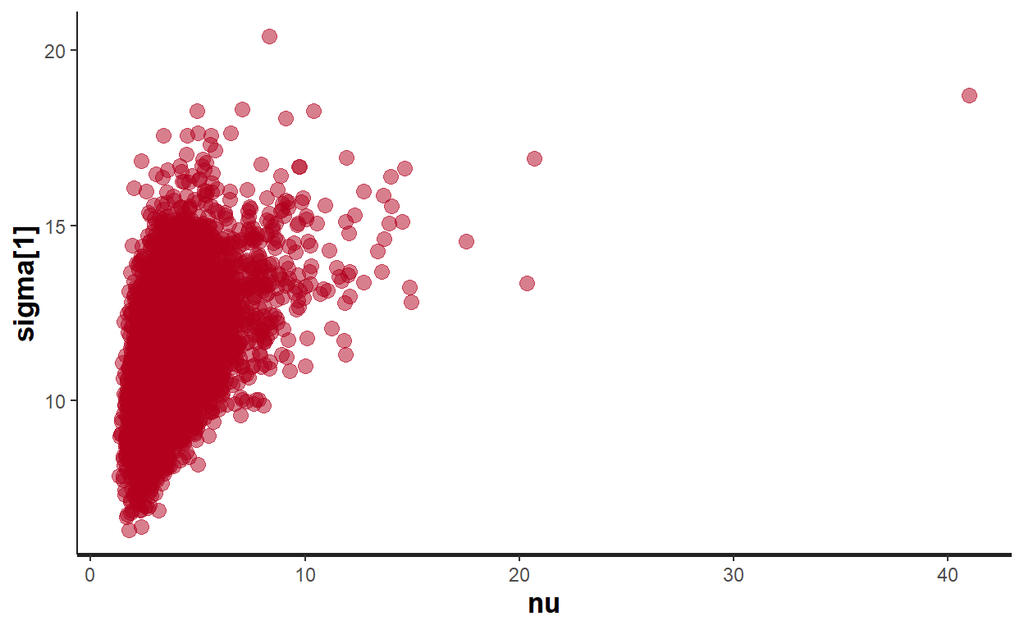

```r
stan_scat(stanFitRobust, c('nu','sigma[1]'))
```

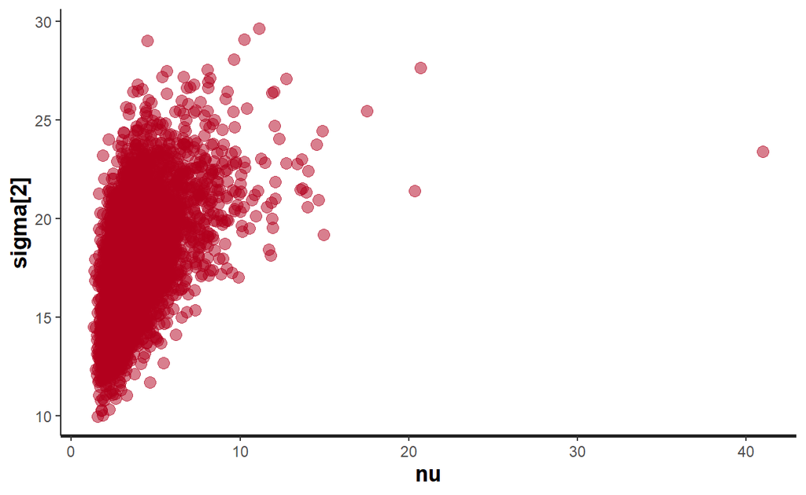

```r
stan_scat(stanFitRobust, c('nu','sigma[2]'))
```

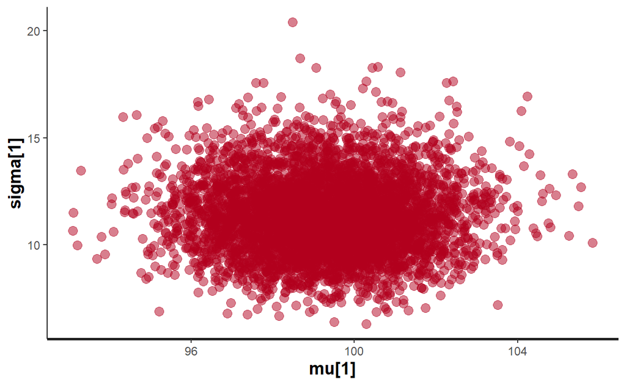

```r
stan_scat(stanFitRobust, c('mu[1]','sigma[1]'))
```

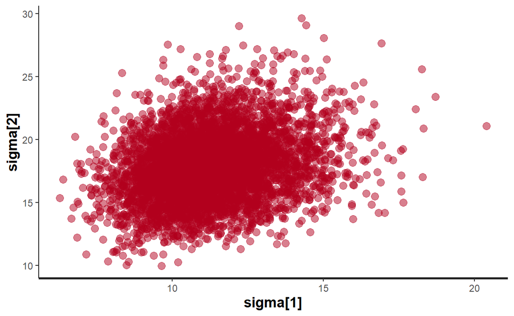

```r
stan_scat(stanFitRobust, c('sigma[1]','sigma[2]'))
```

Note correlation between the sigma parameters.  
**Is there’s maybe no sign of correlation in non-robust approach!**  
**How can you explain positive correlation?**

The difference of scales (i.e., $\sigma_2 − \sigma_1$) shows a credible nonzero difference (*in the below*), suggesting that the smart drug causes greater variance than the placebo.

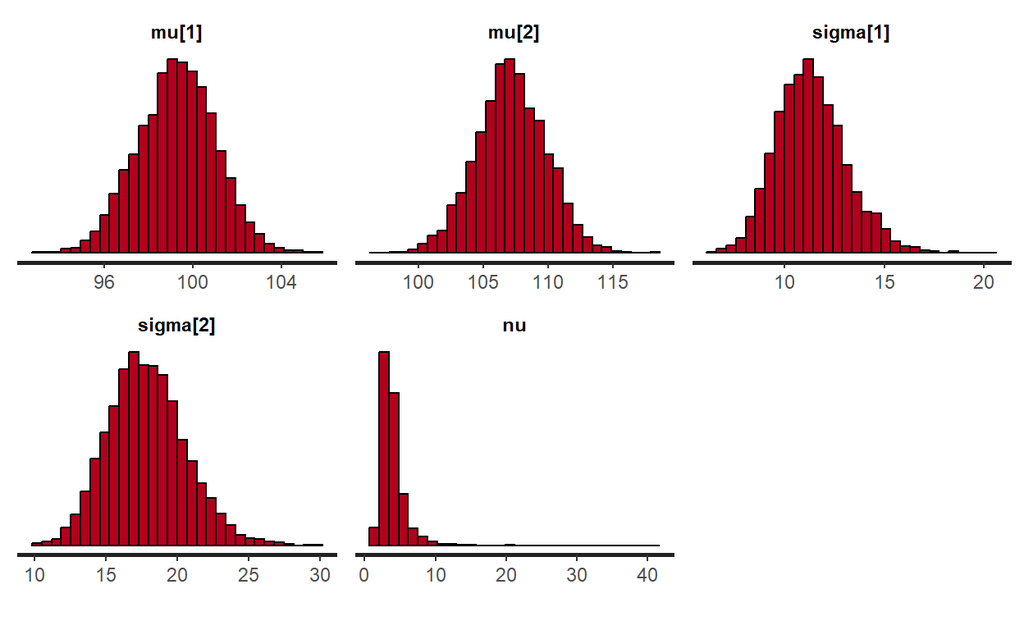

```r
stan_hist(stanFitRobust)
```

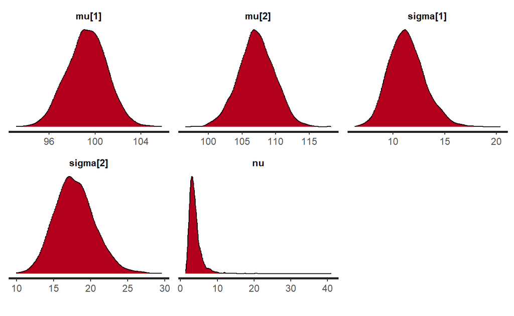

```r
stan_dens(stanFitRobust)
```

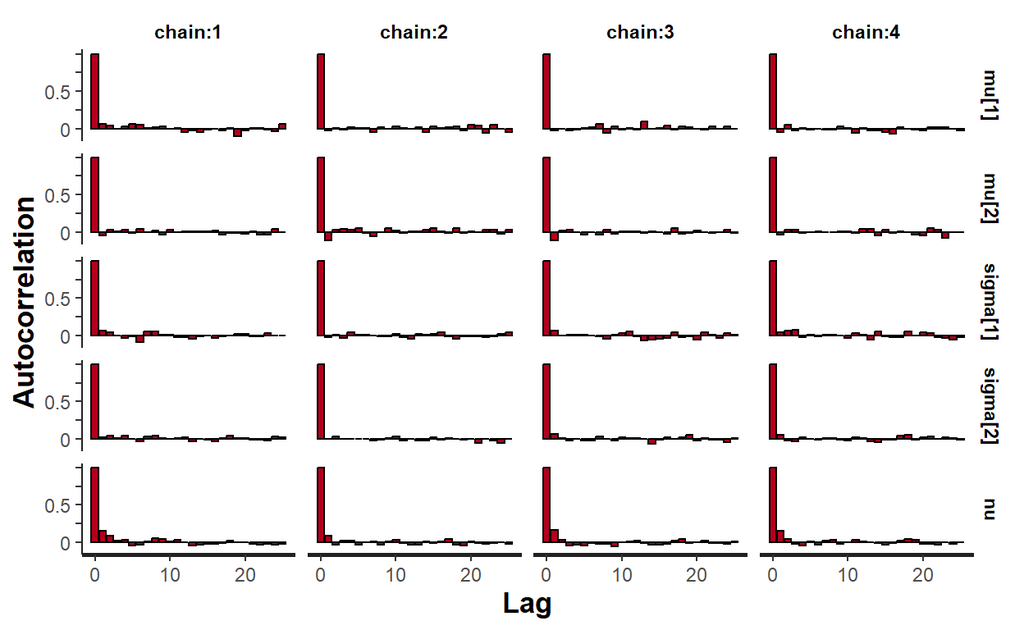

```r
stan_ac(stanFitRobust, separate_chains = T)
```

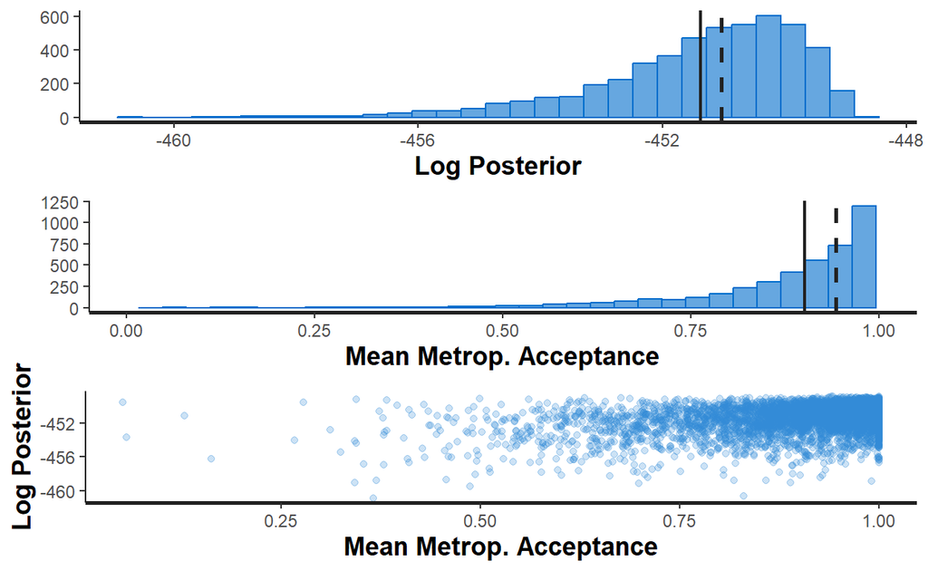

```r
stan_diag(stanFitRobust,information = "sample",chain=0)
```

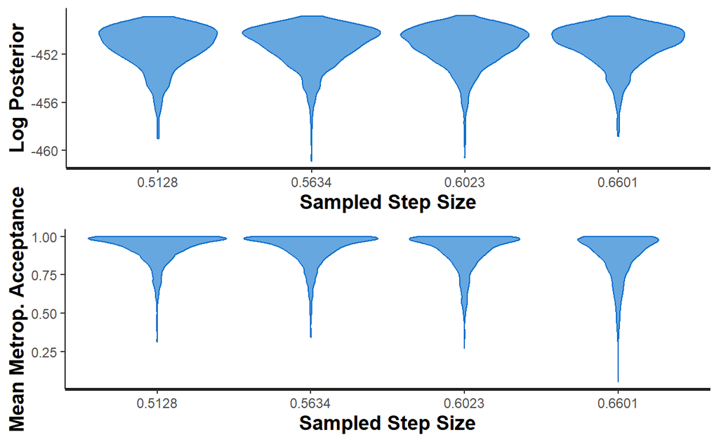

```r
stan_diag(stanFitRobust,information = "stepsize",chain = 0)
```

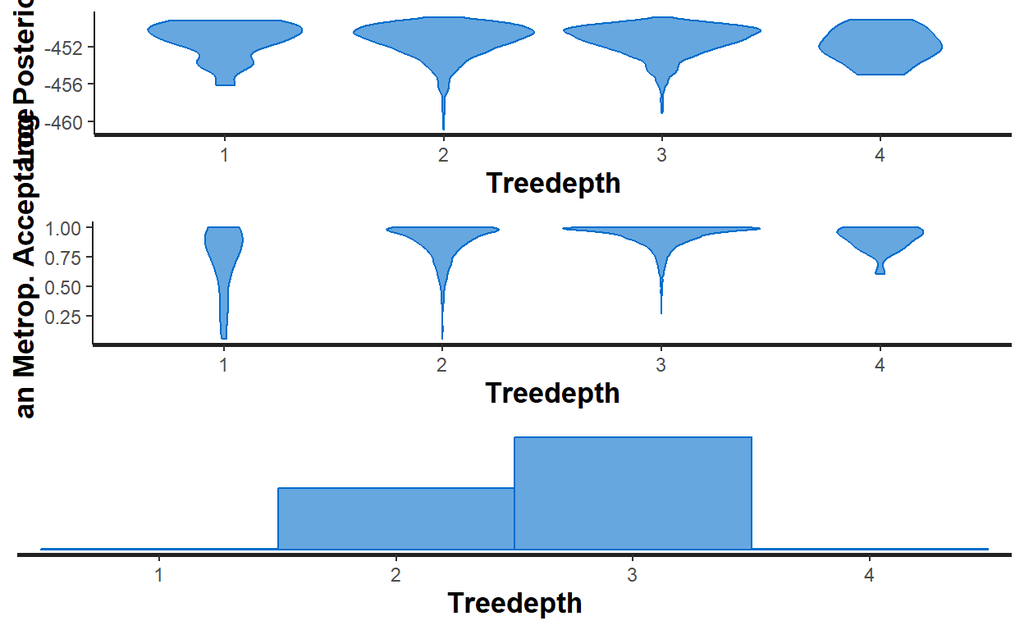

```r
stan_diag(stanFitRobust,information = "treedepth",chain = 0)
```

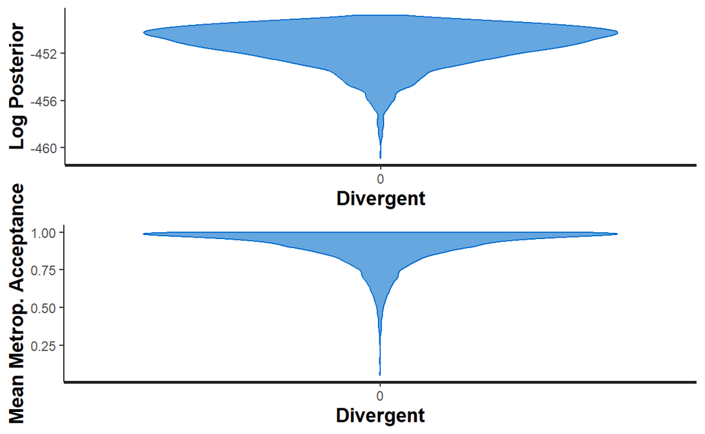

```r
stan_diag(stanFitRobust,information = "divergence",chain = 0)
```

```r
launch_shinystan(stanFitRobust)
```

# Comparison of the groups

## Frequentist probability approach

For comparison decide whether the two groups are different or not, using the Frequentist approach.

Use t-test with unequal variances:

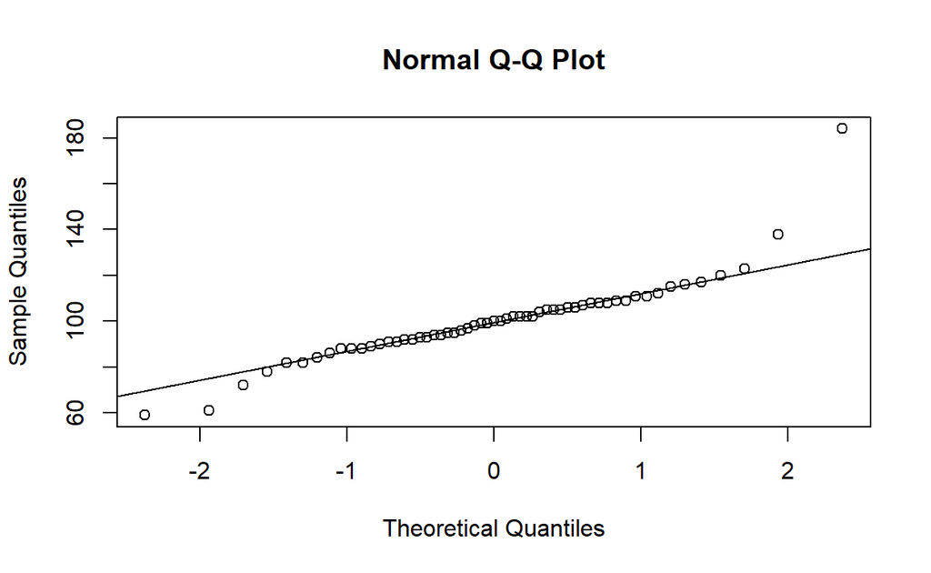

```r
qqnorm(y[x==1])
qqline(y[x==1])
```

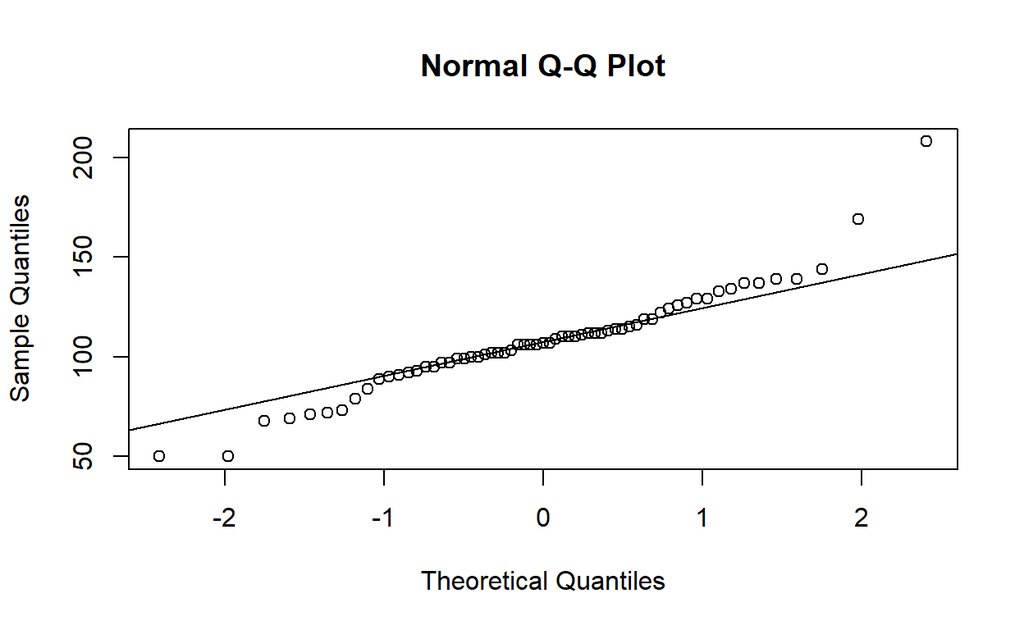

```r
qqnorm(y[x==2])
qqline(y[x==2])
```

```r
t.test(Score ~ Group , data=dta, var.equal=FALSE, paired=FALSE)
```

```
    Welch Two Sample t-test

data:  Score by Group
t = -1.958, df = 111.44, p-value = 0.05273
alternative hypothesis: true difference in means between group Placebo and group Smart Drug is not equal to 0
95 percent confidence interval:
 -15.70602585   0.09366161
sample estimates:
   mean in group Placebo mean in group Smart Drug
                100.0351                 107.8413
```

**Result:** with 5% error I level the null (equality) hypothesis cannot be rejected.  
However, the case is not so clear: the p-value is at the marginal (*very close to 5%*). The sample size is pretty small (*120 observations in both groups*), the result is not very conclusive.  
The test relies on the assumption that distributions of both samples are Gaussian. As we can see in qq-plots this assumption does not hold.

## Bayesian approach

Now use Bayesian approach based on robust estimation.

Create matrices of combined chains for the two means and two standard deviations of the robust fit.

```r
summary(stanFitRobust)
```

```
$summary
                mean    se_mean       sd        2.5%         25%
mu[1]      99.278479 0.02541479 1.757258   95.892836   98.106053
mu[2]     107.135439 0.03759197 2.691692  101.782362  105.356701
sigma[1]   11.324726 0.02646412 1.745481    8.283891   10.114247
sigma[2]   17.871701 0.03961980 2.710205   12.992997   16.008138
nu          3.865007 0.02819681 1.713714    1.906517    2.816141
lp__     -451.375158 0.03470814 1.669462 -455.612524 -452.215782
                 50%         75%       97.5%    n_eff      Rhat
mu[1]      99.318108  100.465290  102.634056 4780.774 1.0001983
mu[2]     107.104442  108.951046  112.281358 5126.967 1.0002329
sigma[1]   11.214309   12.404448   15.055811 4350.261 0.9992927
sigma[2]   17.718447   19.571494   23.554055 4679.288 0.9999055
nu          3.506651    4.418275    8.154027 3693.830 1.0003792
lp__     -451.034452 -450.145225 -449.198416 2313.613 1.0004085

$c_summary
, , chains = chain:1

          stats
parameter        mean       sd        2.5%         25%         50%
  mu[1]      99.31321 1.794266   95.953253   98.116266   99.321257
  mu[2]     106.96172 2.739928  101.452693  105.249842  106.924883
  sigma[1]   11.33591 1.739136    8.295615   10.138611   11.217442
  sigma[2]   17.87345 2.746624   13.081372   15.908501   17.549351
  nu          3.89781 1.758589    1.897855    2.791728    3.522191
  lp__     -451.39555 1.654445 -455.559983 -452.246843 -451.069865
          stats
parameter          75%       97.5%
  mu[1]     100.487503  102.712333
  mu[2]     108.803910  112.141803
  sigma[1]   12.430281   15.144620
  sigma[2]   19.648503   23.691793
  nu          4.469162    8.370698
  lp__     -450.199223 -449.224826

, , chains = chain:2

          stats
parameter         mean       sd        2.5%         25%         50%
```

[output cut: 37 more lines]

```
parameter         mean       sd        2.5%         25%         50%
  mu[1]      99.199874 1.788565   95.891846   97.960787   99.213313
  mu[2]     107.176156 2.544973  102.262461  105.526175  107.097533
  sigma[1]   11.309597 1.742850    8.295669   10.087199   11.227140
  sigma[2]   17.957035 2.665734   13.114103   16.071792   17.869635
  nu          3.924874 1.935407    1.912542    2.882155    3.564496
  lp__     -451.330962 1.643141 -455.604148 -452.095591 -450.986033
          stats
parameter         75%       97.5%
  mu[1]     100.36449  102.632627
  mu[2]     108.81906  112.363129
  sigma[1]   12.38710   14.913067
  sigma[2]   19.68608   23.495363
  nu          4.44298    8.213977
  lp__     -450.10343 -449.228235
```

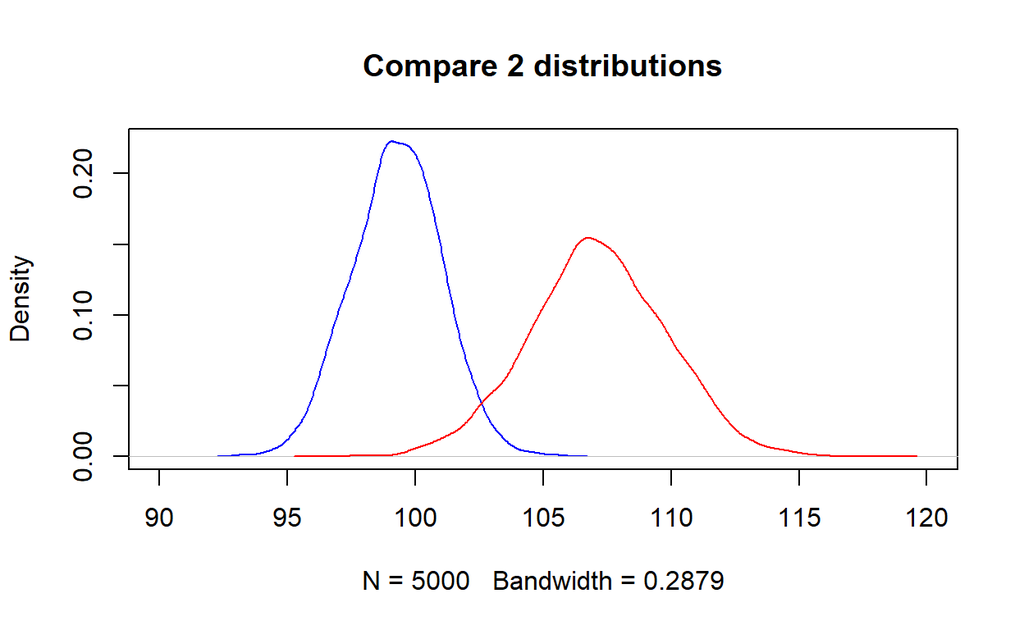

```r
y.dis1<-cbind(Mu=rstan::extract(stanFitRobust,pars="mu[1]")$'mu[1]',
            Sigma=rstan::extract(stanFitRobust,pars="sigma[1]")$'sigma[1]')
y.dis2<-cbind(Mu=rstan::extract(stanFitRobust,pars="mu[2]")$'mu[2]',
            Sigma=rstan::extract(stanFitRobust,pars="sigma[2]")$'sigma[2]')
den.Dis1<-density(y.dis1[, "Mu"])
den.Dis2<-density(y.dis2[, "Mu"])
plot(den.Dis1,col="blue", xlim=c(90,120), main="Compare 2 distributions")
lines(den.Dis2,col="red")
```

Traditional Bayesian approach: look at HDIs.

```r
library(HDInterval)
```

```r
hdi(cbind(y.dis1[,1], y.dis2[,1]), credMass=.9)
```

```
           [,1]     [,2]
lower  96.40157 102.6255
upper 102.14760 111.4564
attr(,"credMass")
[1] 0.9
```

```r
hdi(cbind(y.dis1[,2], y.dis2[,2]), credMass=.85)
```

```
          [,1]     [,2]
lower  8.79751 13.88659
upper 13.71127 21.54786
attr(,"credMass")
[1] 0.85
```

The 95% HDI intervals overlap for both parameters, but with reduced credible mass level they can be distinguished.

### Plot 95% HDI intervals of difference

**Mean difference**

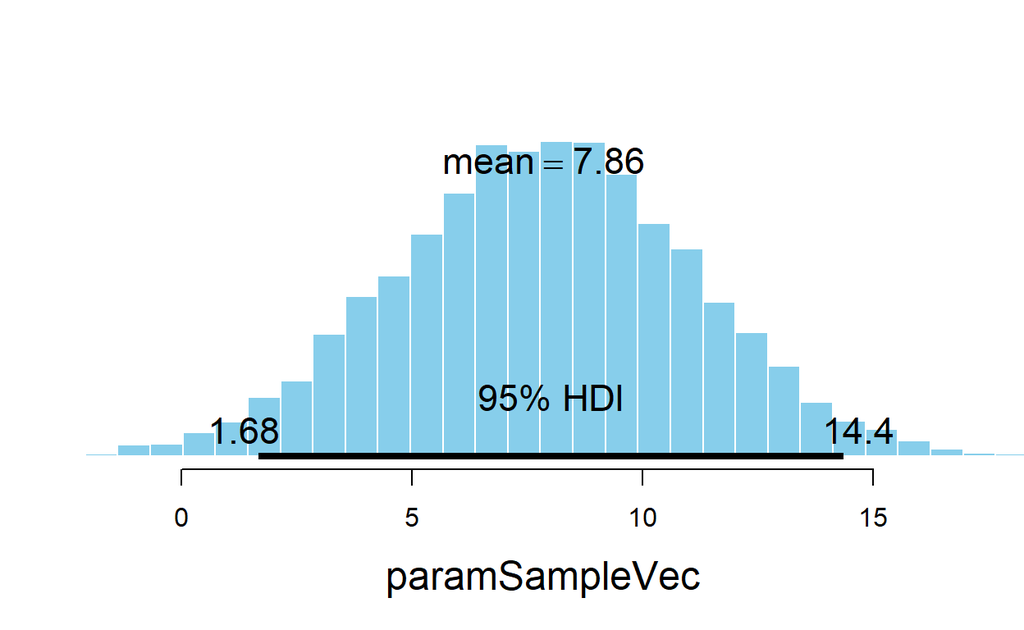

```r
paramSampleVec <- y.dis2[,1] - y.dis1[,1]
plotPost(paramSampleVec=paramSampleVec)
```

**Scale difference**

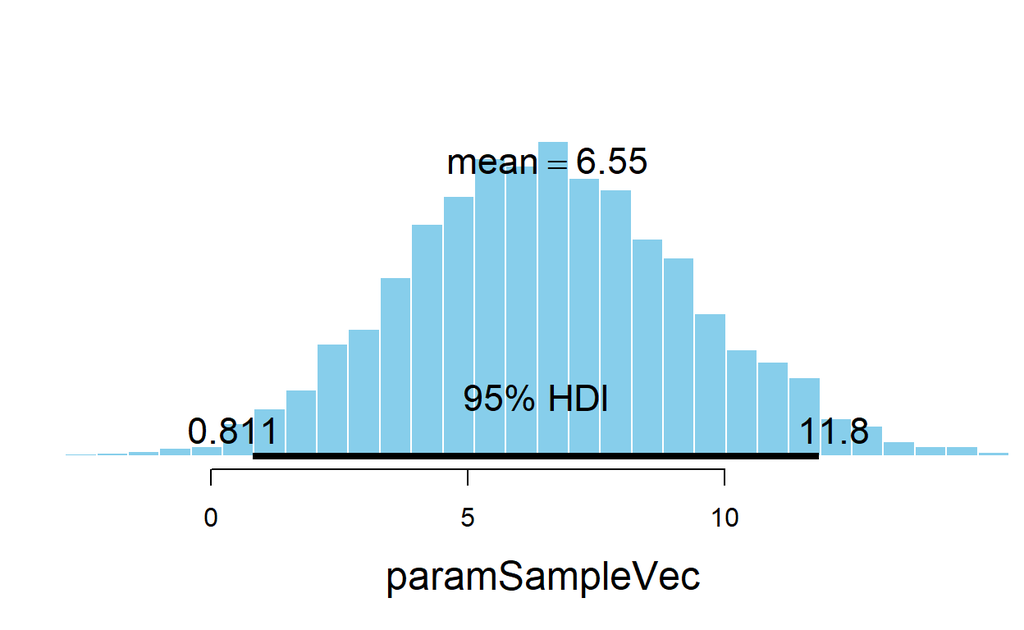

```r
paramSampleVec <- y.dis2[,2] - y.dis1[,2]
plotPost(paramSampleVec=paramSampleVec)
```

## Frequentist probability approach to Markov chains

Apply Frequentist approach to the chain samples.

First, check if the samples for two standard deviations are significantly different or not:

```r
c(mean(y.dis1[,2]),mean(y.dis2[,2])) # mean values
```

```
[1] 11.32473 17.87170
```

```r
c(sd(y.dis1[,2]),sd(y.dis2[,2]))     # standard deviations of samples of MCMC standard deviations
```

```
[1] 1.745481 2.710205
```

```r
ks.test(y.dis1[,2],y.dis2[,2])       # Kolmogorov-Smirnov test for posterior distributions of standard deviations
```

```
    Two-sample Kolmogorov-Smirnov test

data:  y.dis1[, 2] and y.dis2[, 2]
D = 0.862, p-value < 2.2e-16
alternative hypothesis: two-sided
```

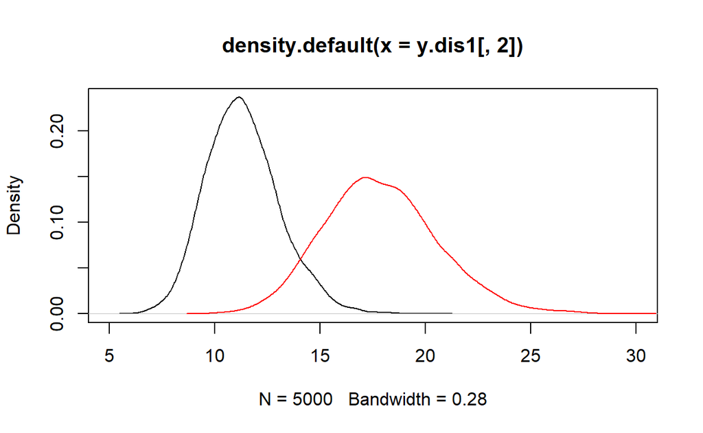

```r
den<-density(y.dis2[,2])
plot(density(y.dis1[,2]),xlim=c(5,30))
lines(den$x,den$y,col="red")
```

```r
t.test(y.dis1[,2],y.dis2[,2], var.equal=F, paired=FALSE) #t-test for means of posterior distributions for standard deviations
```

```
    Welch Two Sample t-test

data:  y.dis1[, 2] and y.dis2[, 2]
t = -143.61, df = 8537.3, p-value < 2.2e-16
alternative hypothesis: true difference in means is not equal to 0
95 percent confidence interval:
 -6.636341 -6.457609
sample estimates:
mean of x mean of y
 11.32473  17.87170
```

Check shapes of the distributions of the mean and standard deviation parameters. How different are they between control and treated groups?

For standard deviations:

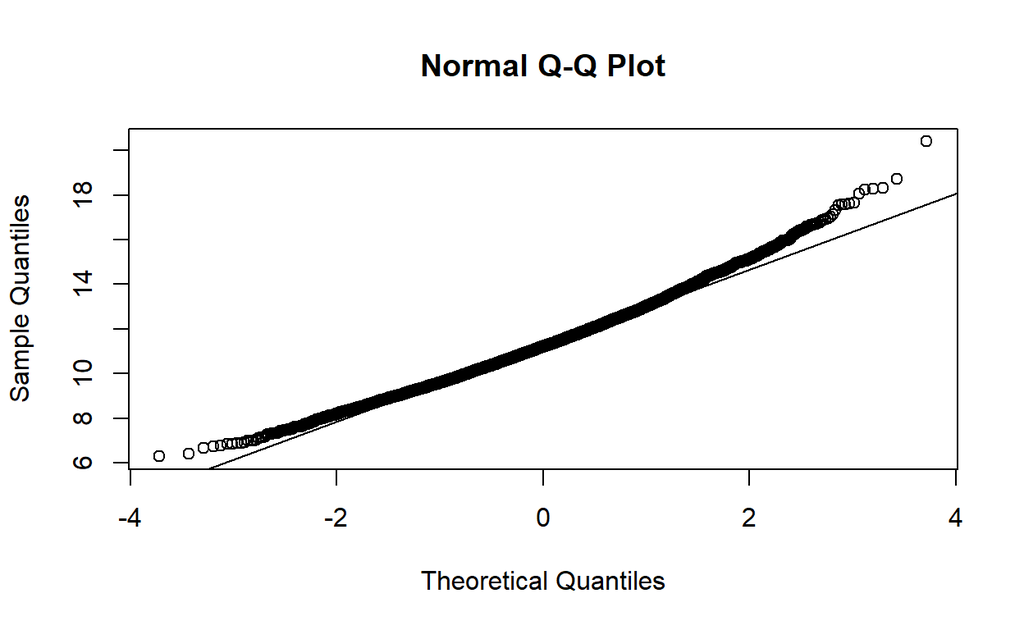

```r
qqnorm(y.dis1[,2])  # control
qqline(y.dis1[,2])
```

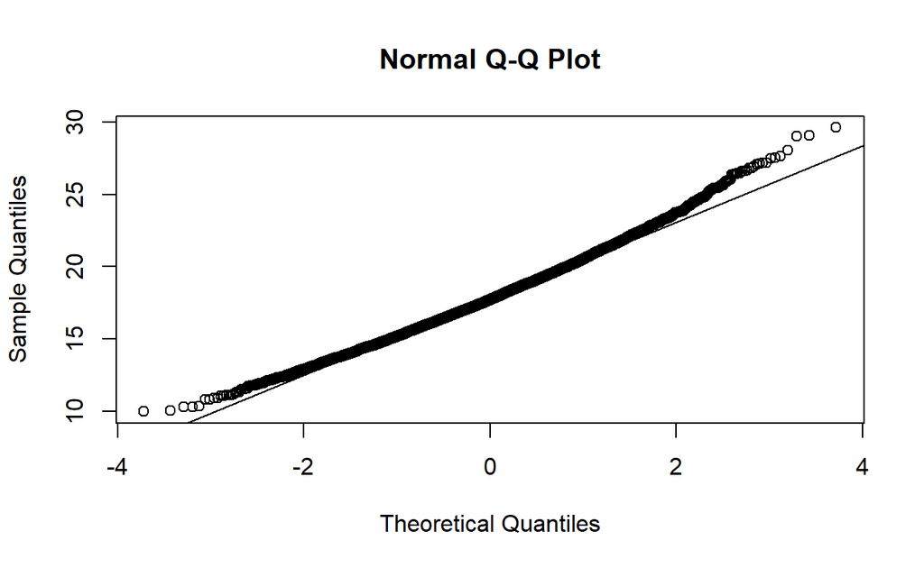

```r
qqnorm(y.dis2[,2])  # treatment
qqline(y.dis2[,2])
```

For mean values:

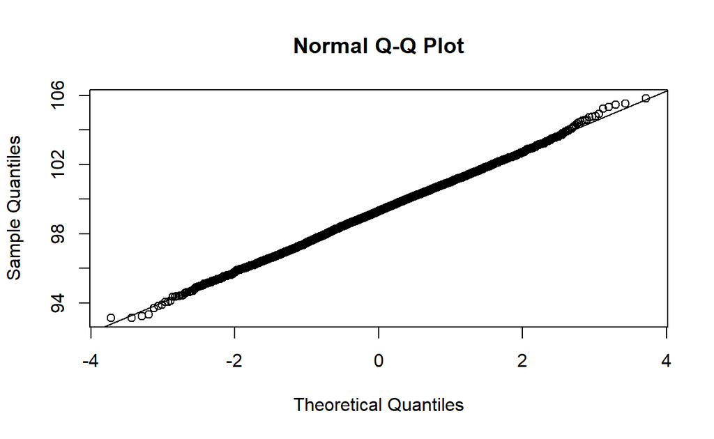

```r
qqnorm(y.dis1[,1])  #control
qqline(y.dis1[,1])
```

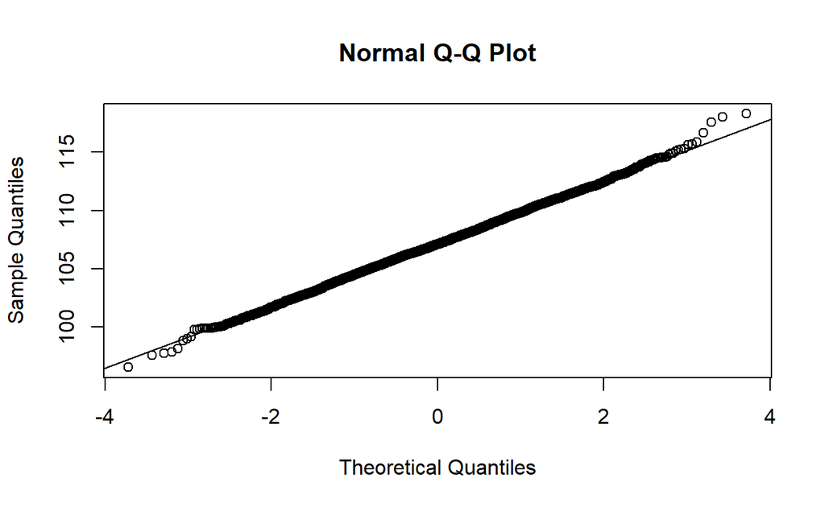

```r
qqnorm(y.dis2[,1])  # treatment
qqline(y.dis2[,1])
```

Comparison of mean and standard deviations of the posterior sample for standard deviations, Kolmogorov-Smirnov test, density plots and t-test for the two samples all indicate that the variances of the two groups are different.

This means that we cannot apply ANOVA to compare the two group mean values directly.

Try t-test for the two means of the posterior distributions with different variances:

```r
t.test(y.dis1[,1],y.dis2[,1], var.equal=F, paired=FALSE)
```

```
    Welch Two Sample t-test

data:  y.dis1[, 1] and y.dis2[, 1]
t = -172.83, df = 8605.2, p-value < 2.2e-16
alternative hypothesis: true difference in means is not equal to 0
95 percent confidence interval:
 -7.946073 -7.767847
sample estimates:
mean of x mean of y
 99.27848 107.13544
```

The null hypothesis of equality of the means of the posterior distributions for the mean values of the two groups decisively rejected: we are testing with a lot longer samples.

Plot the images of the two groups in the mean-standard deviation parameter space:

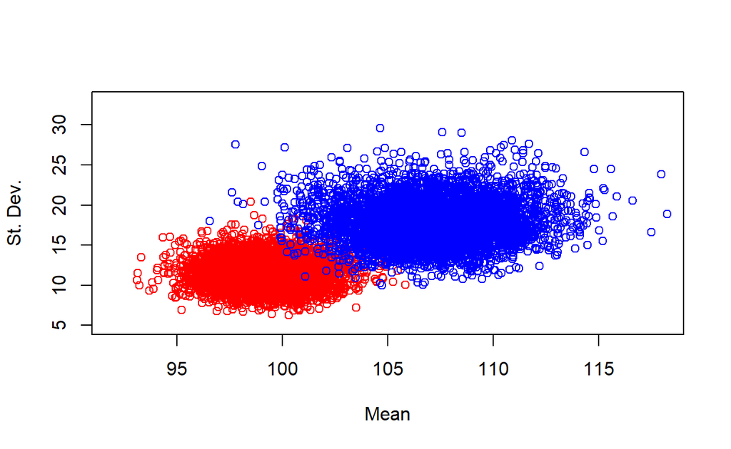

```r
plot(y.dis1,xlim=c(92,118),ylim=c(5,33),col="red",xlab="Mean",ylab="St. Dev.")
points(y.dis2,col="blue")
```

We can see that by using at least 2 different methods proving that there is a significant difference between the 2 groups shown on the plot.

# References

John K. Kruschke, Journal of Experimental Psychology: General, 2013, v.142(2), pp.573-603. (doi: 10.1037/a0029146), [website](https://jkkweb.sitehost.iu.edu/BEST/)

Kruschke, John K. 2015. Doing Bayesian Data Analysis : A Tutorial with r, JAGS, and Stan. Book. 2E [edition]. Amsterdam: Academic Press is an imprint of Elsevier.